# Question2

Varun Agrawal

## Problem 2 : Simulation Study to Understand Sampling Distribution

**Part A** Suppose $X_1,X_2,\cdots,X_n\stackrel{iid}{\sim} Gamma(\alpha,\sigma)$, with pdf as
$$f(x | \alpha,\sigma)=\frac{1}{\sigma^{\alpha}\Gamma(\alpha)}e^{-
x/\sigma}x^{\alpha-1},~~~~0<x<\infty,$$
The mean and variance are $E(X)=\alpha\sigma$ and $Var(X)=\alpha\sigma^2$. Note that `shape =` $\alpha$ and `scale =` $\sigma$.

1. Write a `function` in `R` which will compute the MLE of $\theta=\log(\alpha)$ using `optim` function in `R`. You can name it `MyMLE`

```r
MyMLE <- function(x,alfa,beta){
  est <- function(x1 = x,para){
    est = -1*sum(dgamma(x1,shape = para[1], scale = para[2],log = T))
    return(est)
    }
  opt <- optim(par = c(alfa,beta), fn = est,x1 = x)
  return(log(opt$par[1]))
}
```

```r
Q2_1 <- function(n,N,alfa,beta){
  mle <- c(rep(0,N))
  for(i in 1:N){
    x <- rgamma(n,shape = alfa, scale = beta)
    mle[i] = MyMLE(x,alfa,beta)
  }
  q2_5<- as.character(round(quantile(mle, 0.025),3))
  q97_5<- as.character(round(quantile(mle,0.975),3))
  diff <- as.character(round((quantile(mle,0.975) - quantile(mle, 0.025)),3))

  hist(mle, col = 'skyblue3', breaks = 25)
  abline(v = log(alfa),lwd = 1.5, col = 'red')
  s1 <- as.character(round(log(alfa),2))
  lbl_str <- paste('True Value', s1)
  text(log(alfa),-1,lbl_str,col = 'red')
  print(paste('2.5th quantile = ',q2_5))
  print(paste('97.5th quantile = ',q97_5))
  print(paste('97.5th qunatile - 2.5th quantile = ',diff))
  return(round((quantile(mle,0.975) - quantile(mle, 0.025)),3))
}
```

2. Choose `n=20`, and `alpha=1.5` and `sigma=2.2`
   1. Simulate $\{X_1,X_2,\cdots,X_n\}$ from `rgamma(n=20,shape=1.5,scale=2.2)`
   2. Apply the `MyMLE` to estimate $\theta$ and append the value in a vector
   3. Repeat the step (i) and (ii) 1000 times
   4. Draw histogram of the estimated MLEs of $\theta$.
   5. Draw a vertical line using `abline` function at the true value of $\theta$.
   6. Use `quantile` function on estimated $\theta$’s to find the 2.5 and 97.5-percentile points.

```r
q2 <- Q2_1(20,1000,1.5,2.2)
```

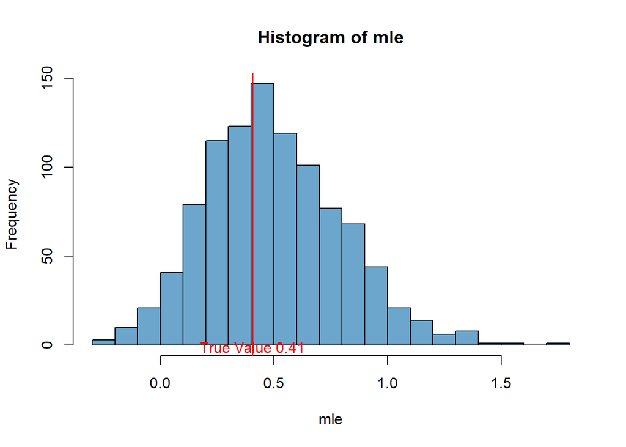

```
## [1] "2.5th quantile =  -0.028"
## [1] "97.5th quantile =  1.128"
## [1] "97.5th qunatile - 2.5th quantile =  1.157"
```

3. Choose `n=40`, and `alpha=1.5` and repeat the (2).

```r
q3 <- Q2_1(40,1000,1.5,2.2)
```

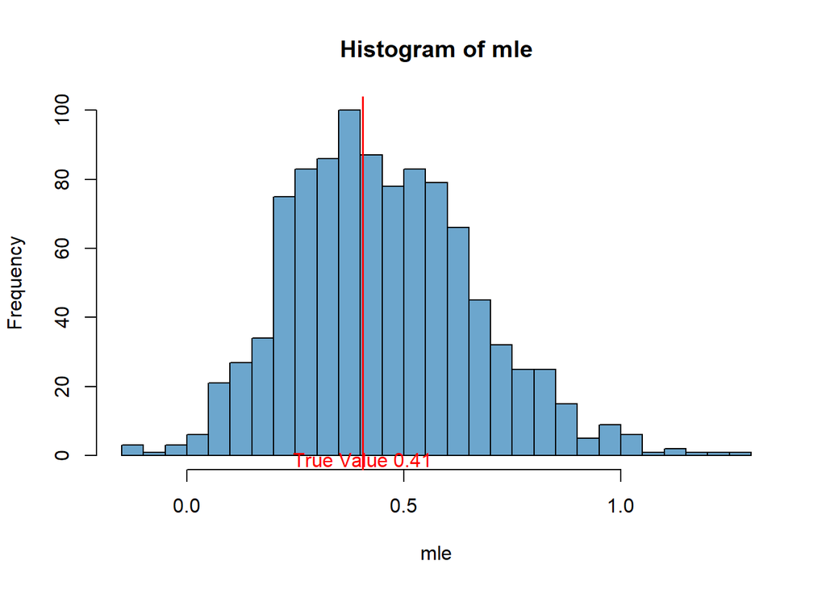

```
## [1] "2.5th quantile =  0.079"
## [1] "97.5th quantile =  0.904"
## [1] "97.5th qunatile - 2.5th quantile =  0.825"
```

4. Choose `n=100`, and `alpha=1.5` and repeat the (2).

```r
q4 <- Q2_1(100,1000,1.5,2.2)
```

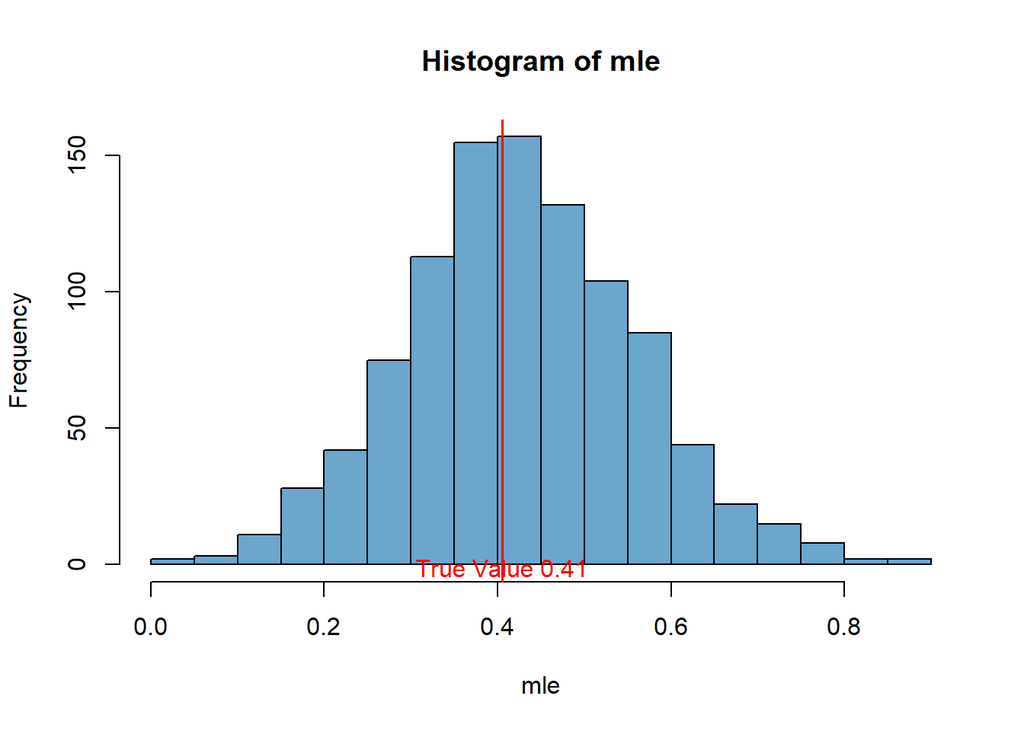

```
## [1] "2.5th quantile =  0.17"
## [1] "97.5th quantile =  0.709"
## [1] "97.5th qunatile - 2.5th quantile =  0.539"
```

5. Check if the gap between 2.5 and 97.5-percentile points are shrinking as sample size `n` is increasing?

```r
print(q2>q3 && q3>q4)
```

```
## [1] TRUE
```

Hence we can see that the gap between 2.5 and 97.5-percentile points are shrinking as sample size `n` is increasing.

*Hint*: Perhaps you should think of writing a single `function` where you will provide the values of `n`, `sim_size`, `alpha` and `sigma`; and it will return the desired output.